# 02_BikeSharingDemand_EDA

### 데이터 탐색해 보기(시각화)

### Kaggle 대회 (Bike Sharing Demand)

- URL : https://www.kaggle.com/
- Competitions 선택하면 다양한 대회 확인 가능.
- 대회 주제 : Bike Sharing Demand
- https://www.kaggle.com/c/bike-sharing-demand

## 데이터 다운로드하기

- 가. https://www.kaggle.com/c/bike-sharing-demand 링크를 선택하여 웹 사이트 접속합니다.
- 나. Data를 선택합니다.
- 다. train.csv, test.csv, sampleSubmission.csv를 다운로드 받습니다.
- 라. 다운로드 받은 csv와 주피터 노트북 또는 py 파일은 동일한 폴더에 위치시킵니다.

[figure not shown]

같은 폴더내에 데이터 파일(csv파일)과 python 노트북 파일을 위치시킵니다.

[figure not shown]

### Data Fields

| 필드명 | 설명 |
| --- | --- |
| datetime | hourly date + timestamp |
| season | 1 = spring, 2 = summer, 3 = fall, 4 = winter |
| holiday | whether the day is considered a holiday |
| workingday | whether the day is neither a weekend nor holiday |
| weather | 1: Clear, Few clouds, Partly cloudy, Partly cloudy 2: Mist + Cloudy, Mist + Broken clouds, Mist + Few clouds, Mist 3: Light Snow, Light Rain + Thunderstorm + Scattered clouds, Light Rain + Scattered c… |
| temp | temperature in Celsius (온도) |
| atemp | "feels like" temperature in Celsius (체감온도) |
| humidity | relative humidity (습도) |
| windspeed | wind speed (바람속도) |
| casual | number of non-registered user rentals initiated (비가입자 사용유저) |
| registered | number of registered user rentals initiated (가입자 사용유저) |
| count | number of total rentals (전체 렌탈 대수) |

### 1-1 라이브러리 불러오기

```python
import pandas as pd
import matplotlib.pyplot as plt ## seaborn 보다 고급 시각화 가능. but 코드 복잡
import seaborn as sns           ## seaborn은 matplotlib보다 간단하게 사용 가능
```

### 1-2 데이터 준비 및 데이터 탐색

- train 은 학습을 위한 데이터 셋
- test 은 예측을 위한 데이터 셋
- ../data/bike : 상위폴더의 (data/bike 폴더 경로), 내 컴퓨터의 데이터 경로 지정.
- parse_dates = [컬럼명] : 해당 컬럼을 시간형 자료로 불러옴.

```python
train = pd.read_csv("../data/bike/train.csv", parse_dates=['datetime'])
test = pd.read_csv("../data/bike/test.csv", parse_dates=['datetime'])
```

### 1-3 간단한 데이터 탐색

- 데이터 행과 열은? (shape)
- 데이터의 개수와 자료형? (info())
- 데이터의 컬럼명은 무엇일까? (columns)
- 몇행만 데이터를 확인해 보자. (head)

```python
print(train.shape)
print(test.shape)
```

```
(10886, 12)
(6493, 9)
```

```python
print(train.info())
print() # 한줄 공백
print(test.info())
```

```
<class 'pandas.core.frame.DataFrame'>
RangeIndex: 10886 entries, 0 to 10885
Data columns (total 12 columns):
 #   Column      Non-Null Count  Dtype
---  ------      --------------  -----
 0   datetime    10886 non-null  datetime64[ns]
 1   season      10886 non-null  int64
 2   holiday     10886 non-null  int64
 3   workingday  10886 non-null  int64
 4   weather     10886 non-null  int64
 5   temp        10886 non-null  float64
 6   atemp       10886 non-null  float64
 7   humidity    10886 non-null  int64
 8   windspeed   10886 non-null  float64
 9   casual      10886 non-null  int64
 10  registered  10886 non-null  int64
 11  count       10886 non-null  int64
dtypes: datetime64[ns](1), float64(3), int64(8)
memory usage: 1020.7 KB
None

<class 'pandas.core.frame.DataFrame'>
RangeIndex: 6493 entries, 0 to 6492
Data columns (total 9 columns):
 #   Column      Non-Null Count  Dtype
---  ------      --------------  -----
 0   datetime    6493 non-null   datetime64[ns]
 1   season      6493 non-null   int64
 2   holiday     6493 non-null   int64
 3   workingday  6493 non-null   int64
 4   weather     6493 non-null   int64
 5   temp        6493 non-null   float64
 6   atemp       6493 non-null   float64
 7   humidity    6493 non-null   int64
 8   windspeed   6493 non-null   float64
dtypes: datetime64[ns](1), float64(3), int64(5)
memory usage: 456.7 KB
None
```

- 기본적으로 데이터 셋은 실수형(float)과 정수형(int)로 이루어져 있다.
- non-null : 결측치가 없음.

```python
print(train.columns)
print()
print(test.columns)
```

```
Index(['datetime', 'season', 'holiday', 'workingday', 'weather', 'temp',
       'atemp', 'humidity', 'windspeed', 'casual', 'registered', 'count'],
      dtype='object')

Index(['datetime', 'season', 'holiday', 'workingday', 'weather', 'temp',
       'atemp', 'humidity', 'windspeed'],
      dtype='object')
```

```python
train.head()
```

|  | datetime | season | holiday | workingday | weather | temp | atemp | humidity | windspeed | casual | registered | count |
| --- | --- | --- | --- | --- | --- | --- | --- | --- | --- | --- | --- | --- |
| 0 | 2011-01-01 00:00:00 | 1 | 0 | 0 | 1 | 9.84 | 14.395 | 81 | 0.0 | 3 | 13 | 16 |
| 1 | 2011-01-01 01:00:00 | 1 | 0 | 0 | 1 | 9.02 | 13.635 | 80 | 0.0 | 8 | 32 | 40 |
| 2 | 2011-01-01 02:00:00 | 1 | 0 | 0 | 1 | 9.02 | 13.635 | 80 | 0.0 | 5 | 27 | 32 |
| 3 | 2011-01-01 03:00:00 | 1 | 0 | 0 | 1 | 9.84 | 14.395 | 75 | 0.0 | 3 | 10 | 13 |
| 4 | 2011-01-01 04:00:00 | 1 | 0 | 0 | 1 | 9.84 | 14.395 | 75 | 0.0 | 0 | 1 | 1 |

```python
train.tail()
```

|  | datetime | season | holiday | workingday | weather | temp | atemp | humidity | windspeed | casual | registered | count |
| --- | --- | --- | --- | --- | --- | --- | --- | --- | --- | --- | --- | --- |
| 10881 | 2012-12-19 19:00:00 | 4 | 0 | 1 | 1 | 15.58 | 19.695 | 50 | 26.0027 | 7 | 329 | 336 |
| 10882 | 2012-12-19 20:00:00 | 4 | 0 | 1 | 1 | 14.76 | 17.425 | 57 | 15.0013 | 10 | 231 | 241 |
| 10883 | 2012-12-19 21:00:00 | 4 | 0 | 1 | 1 | 13.94 | 15.910 | 61 | 15.0013 | 4 | 164 | 168 |
| 10884 | 2012-12-19 22:00:00 | 4 | 0 | 1 | 1 | 13.94 | 17.425 | 61 | 6.0032 | 12 | 117 | 129 |
| 10885 | 2012-12-19 23:00:00 | 4 | 0 | 1 | 1 | 13.12 | 16.665 | 66 | 8.9981 | 4 | 84 | 88 |

### 1-4 데이터 시각화를 통한 데이터 이해

#### (A) Count- Rental 대수 boxplot(상자그림) 보기

```
count    10886.000000
mean       191.574132
std        181.144454
min          1.000000
25%         42.000000
50%        145.000000
75%        284.000000
max        977.000000
Name: count, dtype: float64
```

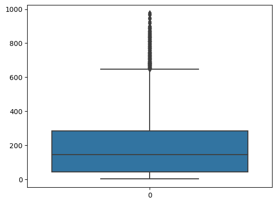

```python
print(train['count'].describe())
sns.boxplot(train['count'])
```

- 데이터(렌탈 대수의 분포) 확인 결과 25% ~ 75% 는 42대~284대로 분포해 있음.
- Boxplot상으로의 아웃라이어로 보여지는 것도 확인된다.

- 연속형 데이터에 대한 히스토그램도 그려보자.
- 이번에는 matplotlib.pyplot 의 hist를 활용해 본다.

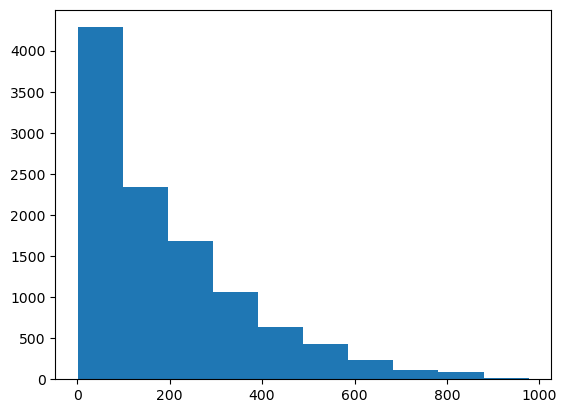

```python
plt.hist(train['count'])
```

### 데이터를 통해 확인된 범주형 데이터에 대한 막대그래프 확인해 보기

[output not shown]

[figure not shown]

```python
col_names = [ 'season', 'holiday', 'workingday', 'weather'  ]
i = 0
plt.figure(figsize=(12,10))   # 전체 그래프의 크기 지정 (가로, 세로)

for name in col_names:        # 컬럼명을 전달 리스트 수 만큼 반복 -> 4회
    i = i + 1                 # 숫자를 1씩 증가.
    plt.subplot(2,2,i)        # 2행 2열에 i번째 그래프 선택
    sns.countplot(name, data=train)  # i번째 그래프에 sns.countplot를 그리겠다.

# 주피터에서 아래 행이 필요없지만,
# 다른곳(editor, pycharm)에서는(*.py 파일) plt.show()이걸 실행시켜야 한다.
plt.show()
```

### train과 test를 비교해서 확인해 보자

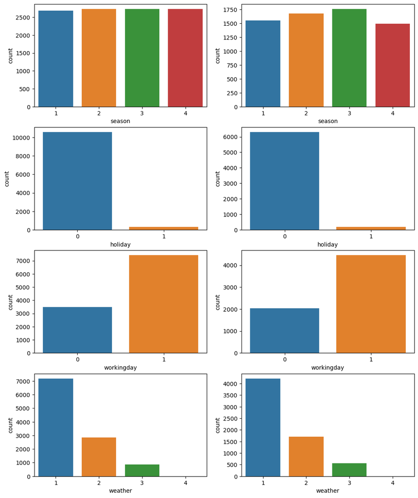

```python
col_names = [ 'season', 'holiday', 'workingday', 'weather'  ]
i = 0
plt.figure(figsize=(12,15))   # 전체 그래프의 크기 지정 (가로, 세로)

for name in col_names:        # 컬럼명을 전달 리스트 수 만큼 반복 -> 4회
    i = i + 1                 # 숫자를 1씩 증가.
    plt.subplot(4,2,i*2-1)        # 2행 2열에 i번째 그래프 선택
    sns.countplot(x=name, data=train)  # i번째 그래프에 sns.countplot를 그리겠다.
    plt.subplot(4,2,i*2)        # 2행 2열에 i번째 그래프 선택
    sns.countplot(x=name, data=test)  # i번째 그래프에 sns.countplot를 그리겠다.


# 주피터에서 아래 행이 필요없지만,
# 다른곳(editor, pycharm)에서는(*.py 파일) plt.show()이걸 실행시켜야 한다.
plt.show()
```

- train과 test의 비교시, test에 season별 렌탈 대수 분포가 다른 것을 볼 수 있다.

```python
### temp, atemp, humidity, windspeed
num_names = ['temp', 'atemp', 'humidity', 'windspeed']
train.columns
```

```
Index(['datetime', 'season', 'holiday', 'workingday', 'weather', 'temp',
       'atemp', 'humidity', 'windspeed', 'casual', 'registered', 'count'],
      dtype='object')
```

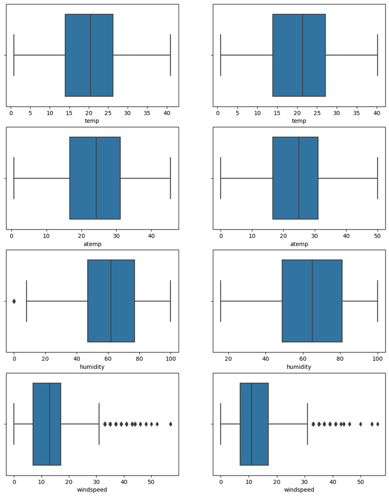

```python
# par(mfrow=c(2,2)) -> R

i = 0
plt.figure(figsize=(12,15))   # 전체 그래프의 크기 지정 (가로, 세로)

for name in num_names:        # 컬럼명을 전달 리스트 수 만큼 반복 -> 4회
    i = i + 1                 # 숫자를 1씩 증가.
    plt.subplot(4,2,i*2-1)        # 2행 2열에 i번째 그래프 선택
    sns.boxplot(x=name, data=train)  # i번째 그래프에 sns.countplot를 그리겠다.
    plt.subplot(4,2,i*2)        # 2행 2열에 i번째 그래프 선택
    sns.boxplot(x=name, data=test)  # i번째 그래프에 sns.countplot를 그리겠다.

plt.show()
```

- 전반적으로 값의 분포가 비슷하며, 간간히 이상치가 보인다.

### 1-5 데이터 새로운 컬럼을 만들어보기

```python
new_tr = train   # 데이터 백업
new_test = test
new_tr.columns
```

```
Index(['datetime', 'season', 'holiday', 'workingday', 'weather', 'temp',
       'atemp', 'humidity', 'windspeed', 'casual', 'registered', 'count'],
      dtype='object')
```

### 데이터 셋 (백업)

```python
new_tr = train
new_test = test
new_tr.columns
```

```
Index(['datetime', 'season', 'holiday', 'workingday', 'weather', 'temp',
       'atemp', 'humidity', 'windspeed', 'casual', 'registered', 'count'],
      dtype='object')
```

```python
new_tr.info()
```

```
<class 'pandas.core.frame.DataFrame'>
RangeIndex: 10886 entries, 0 to 10885
Data columns (total 12 columns):
 #   Column      Non-Null Count  Dtype
---  ------      --------------  -----
 0   datetime    10886 non-null  datetime64[ns]
 1   season      10886 non-null  int64
 2   holiday     10886 non-null  int64
 3   workingday  10886 non-null  int64
 4   weather     10886 non-null  int64
 5   temp        10886 non-null  float64
 6   atemp       10886 non-null  float64
 7   humidity    10886 non-null  int64
 8   windspeed   10886 non-null  float64
 9   casual      10886 non-null  int64
 10  registered  10886 non-null  int64
 11  count       10886 non-null  int64
dtypes: datetime64[ns](1), float64(3), int64(8)
memory usage: 1020.7 KB
```

```python
new_tr['datetime'].dt.day.head()
```

```
0    1
1    1
2    1
3    1
4    1
Name: datetime, dtype: int32
```

```python
new_test['datetime'].dt.day.head()
```

```
0    20
1    20
2    20
3    20
4    20
Name: datetime, dtype: int32
```

### 날짜에서 년도를 정보를 갖는 컬럼 만들기

```python
## 더미변수, 파생변수 생성
new_tr['year'] = new_tr['datetime'].dt.year
new_tr.head()
```

|  | datetime | season | holiday | workingday | weather | temp | atemp | humidity | windspeed | casual | registered | count | year |
| --- | --- | --- | --- | --- | --- | --- | --- | --- | --- | --- | --- | --- | --- |
| 0 | 2011-01-01 00:00:00 | 1 | 0 | 0 | 1 | 9.84 | 14.395 | 81 | 0.0 | 3 | 13 | 16 | 2011 |
| 1 | 2011-01-01 01:00:00 | 1 | 0 | 0 | 1 | 9.02 | 13.635 | 80 | 0.0 | 8 | 32 | 40 | 2011 |
| 2 | 2011-01-01 02:00:00 | 1 | 0 | 0 | 1 | 9.02 | 13.635 | 80 | 0.0 | 5 | 27 | 32 | 2011 |
| 3 | 2011-01-01 03:00:00 | 1 | 0 | 0 | 1 | 9.84 | 14.395 | 75 | 0.0 | 3 | 10 | 13 | 2011 |
| 4 | 2011-01-01 04:00:00 | 1 | 0 | 0 | 1 | 9.84 | 14.395 | 75 | 0.0 | 0 | 1 | 1 | 2011 |

```python
new_tr['month'] = new_tr['datetime'].dt.month
new_tr['day'] = new_tr['datetime'].dt.day
new_tr['hour'] = new_tr['datetime'].dt.hour
new_tr['minute'] = new_tr['datetime'].dt.minute
new_tr['second'] = new_tr['datetime'].dt.second
new_tr['dayofweek'] = new_tr['datetime'].dt.dayofweek
new_tr[  ['datetime', 'year', 'month', 'day', 'hour', 'dayofweek']   ]
```

|  | datetime | year | month | day | hour | dayofweek |
| --- | --- | --- | --- | --- | --- | --- |
| 0 | 2011-01-01 00:00:00 | 2011 | 1 | 1 | 0 | 5 |
| 1 | 2011-01-01 01:00:00 | 2011 | 1 | 1 | 1 | 5 |
| 2 | 2011-01-01 02:00:00 | 2011 | 1 | 1 | 2 | 5 |
| 3 | 2011-01-01 03:00:00 | 2011 | 1 | 1 | 3 | 5 |
| 4 | 2011-01-01 04:00:00 | 2011 | 1 | 1 | 4 | 5 |
| ... | ... | ... | ... | ... | ... | ... |
| 10881 | 2012-12-19 19:00:00 | 2012 | 12 | 19 | 19 | 2 |
| 10882 | 2012-12-19 20:00:00 | 2012 | 12 | 19 | 20 | 2 |
| 10883 | 2012-12-19 21:00:00 | 2012 | 12 | 19 | 21 | 2 |
| 10884 | 2012-12-19 22:00:00 | 2012 | 12 | 19 | 22 | 2 |
| 10885 | 2012-12-19 23:00:00 | 2012 | 12 | 19 | 23 | 2 |

10886 rows × 6 columns

### 생성된 컬럼에 대한 시각화

```python
train.columns
```

```
Index(['datetime', 'season', 'holiday', 'workingday', 'weather', 'temp',
       'atemp', 'humidity', 'windspeed', 'casual', 'registered', 'count',
       'year', 'month', 'day', 'hour', 'minute', 'second', 'dayofweek'],
      dtype='object')
```

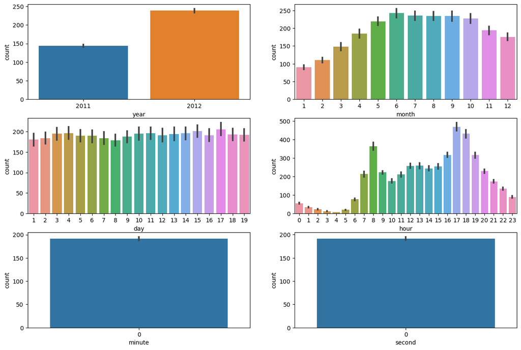

```python
datetime_names = ['year', 'month', 'day', 'hour', 'minute', 'second']

i=0
plt.figure(figsize=(15,10))
for name in datetime_names:
    i = i + 1
    plt.subplot(3,2,i)
    sns.barplot(x=name, y='count', data=new_tr)

plt.show()
```

## 확인

- 2011년, 2012년이 더 많다. (성장했는가?)
- 여름이 많다.
- day는 고른 분포를 보인다.
- hour는 8시, 17,18시대에 많다. (새벽 시간대도 있구나... 음.)
- minute, second는 0 데이터 의미가 없음.

### 실습해 보기

- 테스트 데이터 셋에 대해 확인

```python
new_test['year'] = new_test['datetime'].dt.year
new_test['month'] = new_test['datetime'].dt.month
new_test['day'] = new_test['datetime'].dt.day
new_test['dayofweek'] = new_test['datetime'].dt.dayofweek
new_test['hour'] = new_test['datetime'].dt.hour
new_test['minute'] = new_test['datetime'].dt.minute
new_test['second'] = new_test['datetime'].dt.second
```

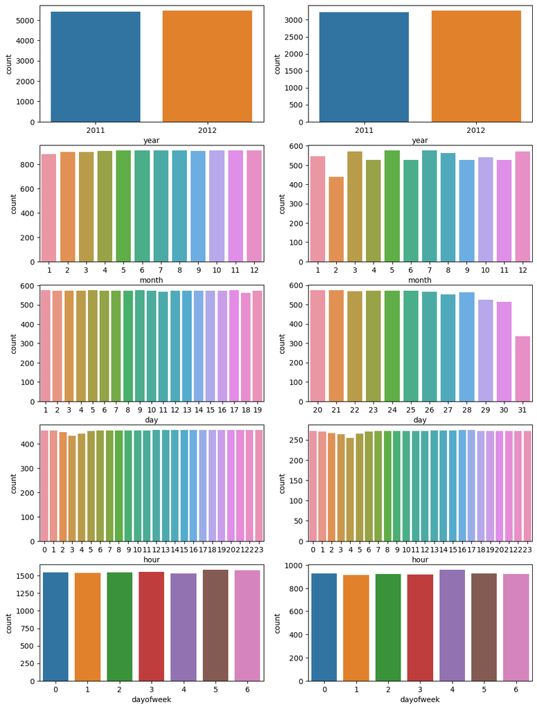

```python
col_names = ['year','month','day','hour','dayofweek']
i = 0

plt.figure(figsize=(12,20))  ##전체 그래프 크기 지정

for name in col_names: ## 컬럼명으로 반복
  i = i+1
  plt.subplot(6,2,i)  ##2행2열, i = 1,2,3,4 (왼쪽 상단부터 시계방향으로 순번 지정)
  sns.countplot(x=name, data = new_tr)

  i = i+1
  plt.subplot(6,2,i)  ##2행2열, i = 1,2,3,4 (왼쪽 상단부터 시계방향으로 순번 지정)
  sns.countplot(x=name, data = new_test)

plt.show()
```

### Heatmap를 통한 상관계수 확인

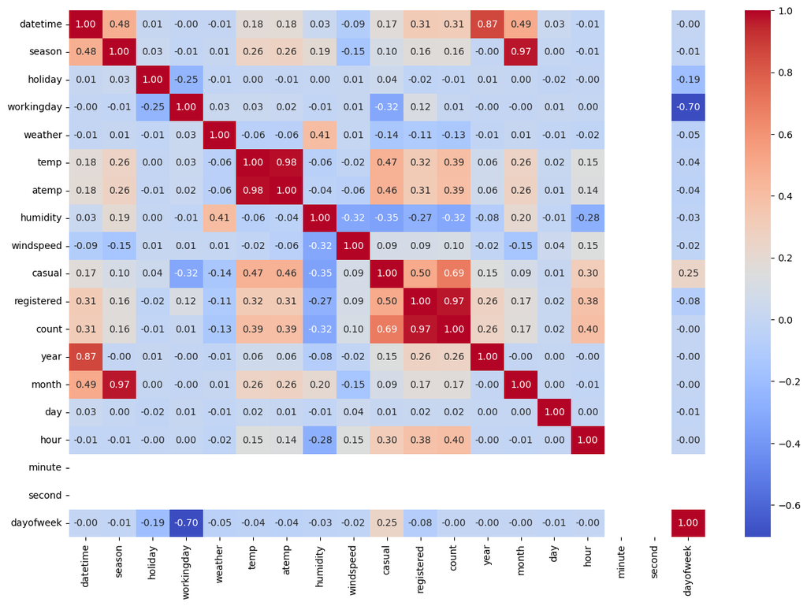

```python
plt.figure(figsize=(15,10))
g = sns.heatmap(new_tr.corr(), annot=True, fmt=".2f", cmap="coolwarm")
```

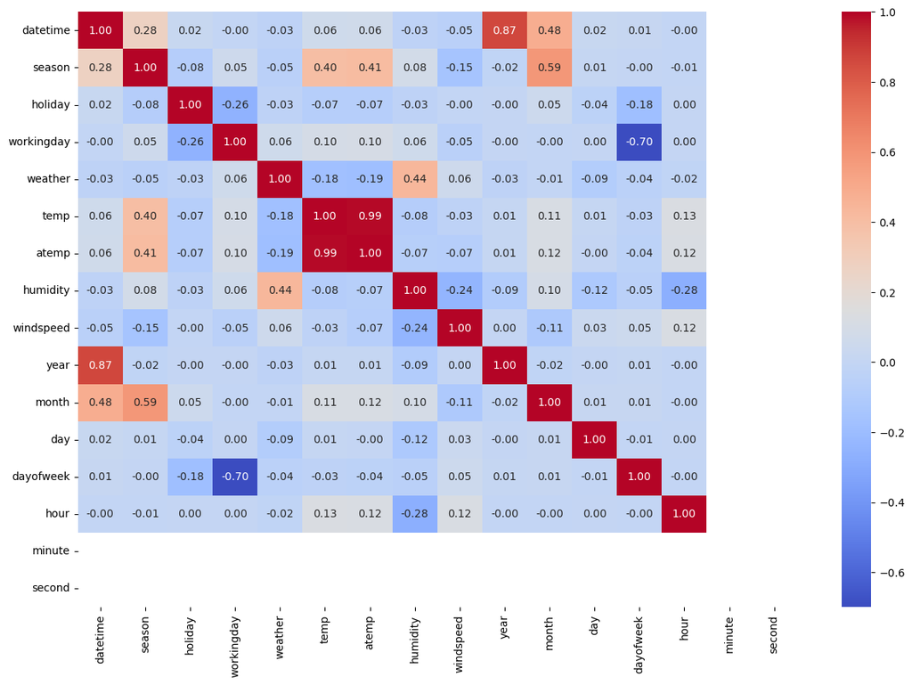

```python
plt.figure(figsize=(15,10))
g = sns.heatmap(new_test.corr(), annot=True, fmt=".2f", cmap="coolwarm")
```